# SzCausalSummary

```r
# marginal association for Avr.spineS in Sz and Controls
limresSz = fitLimma(protein[,SzP], modSpine[which(pheno$Group=="Sz"),], "spineD - 0")
limresCtrl = fitLimma(protein[,Ctrl], modSpine[which(pheno$Group=="C"),], "spineD - 0")
topTable(limresSz)
```

```
##               logFC     AveExpr        t      P.Value adj.P.Val         B
## pP17096.4 1.0756418  0.28145853 4.268223 2.321618e-05 0.3979950 -3.265292
## pQ92688   1.0077131 -0.44406577 4.012478 6.843059e-05 0.5865528 -3.425685
## pQ6IQ19   0.9676038 -0.37448605 3.803591 1.586395e-04 0.6436434 -3.550098
## pQ9H706   0.9581040 -0.41943871 3.789843 1.674420e-04 0.6436434 -3.558076
## pQ969T4   0.9530234 -0.33394129 3.734906 2.074311e-04 0.6436434 -3.589693
## RL37A.syn 0.9376995 -0.18918192 3.713557 2.252733e-04 0.6436434 -3.601867
## pQ15057   0.8826156 -0.03376813 3.481205 5.389212e-04 0.9094734 -3.730232
## pQ6H8Q1.6 0.8825834 -0.15424995 3.480261 5.407822e-04 0.9094734 -3.730738
## pP23468.1 0.8644651  0.03465700 3.432091 6.441229e-04 0.9094734 -3.756390
## pO15027.2 0.8484686 -0.18462014 3.335929 9.076863e-04 0.9094734 -3.806612
```

```r
topTable(limresCtrl)
```

```
##                 logFC     AveExpr         t      P.Value adj.P.Val         B
## PPM1E.syn  -0.9458450 -0.34740985 -3.473051 0.0006771436 0.9999921 -3.961855
## pQ96IZ7     0.8914463 -0.07009488  3.386813 0.0009085221 0.9999921 -3.993812
## pQ15036.2   0.8970421  0.13330417  3.341981 0.0010562638 0.9999921 -4.010195
## pO75190.1  -0.8579486 -0.36272190 -3.267242 0.0013534502 0.9999921 -4.037149
## pQ9UQ35.87  0.8792725 -0.46504635  3.245957 0.0014513746 0.9999921 -4.044743
## HNRPC.syn  -0.8435109  0.05558890 -3.217678 0.0015916982 0.9999921 -4.054774
## pQ5T200.4   0.8420023 -0.07732842  3.160574 0.0019143067 0.9999921 -4.074829
## pP19634.4   0.8300463  0.48413324  3.153196 0.0019601525 0.9999921 -4.077400
## pQ09470.2   0.8230990  0.34378664  3.129157 0.0021166955 0.9999921 -4.085746
## pO60241.1  -0.8342739 -0.30105360 -3.094255 0.0023646789 0.9999921 -4.097777
```

```r
resGN.spineSz = runGnetMulti(t(protein[,SzP]), y=spine.dens[7,SzP], nfolds=3, bootstrap = T, alpha = 0.9)
```

```
## family is set to gaussian
```

```r
resGN.spineCtrl = runGnetMulti(t(protein[,Ctrl]), y=spine.dens[7,Ctrl], nfolds=3, bootstrap = T, alpha = 0.9)
```

```
## family is set to gaussian
```

```r
# hist(resGN.spineSz$features[resGN.spineSz$features > 0], main = "resGN.spineSz_features") + title(sub="alpha=0.9")
# hist(resGN.spineCtrl$features[resGN.spineCtrl$features > 0], main = "resGN.spineCtrl_features") + title(sub="alpha=0.9")
```

```r
toLabel.SpineSz = rownames(protein)[which(resGN.spineSz$features>5 | abs(limresSz$t)>3.5)]
length(toLabel.SpineSz) #do not plot more than 30 labels, they will be subsampled
```

```
## [1] 11
```

```r
toLabel.SpineCtrl = rownames(protein)[which(resGN.spineCtrl$features>5 | abs(limresCtrl$t)>3)]
length(toLabel.SpineCtrl) #do not plot more than 30 labels, they will be subsampled
```

```
## [1] 20
```

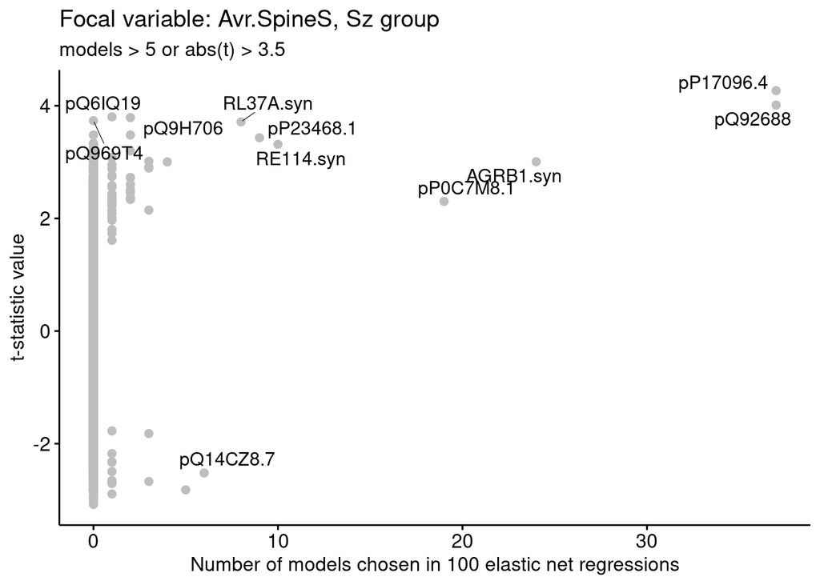

```r
myggscatter(resGN.spineSz$features, limresSz$t, line = F, label = rownames(protein),
            xlab="Number of models chosen in 100 elastic net regressions",
            ylab="t-statistic value",
            label.select = toLabel.SpineSz,
            title="Focal variable: Avr.SpineS, Sz group", subtitle = "models > 5 or abs(t) > 3.5")
```

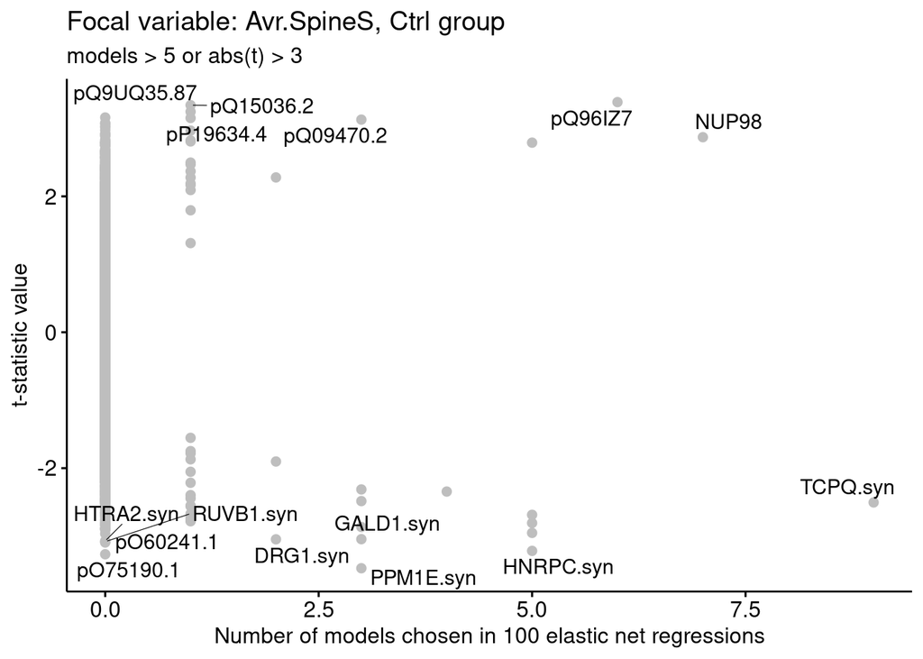

```r
myggscatter(resGN.spineCtrl$features, limresCtrl$t, line = F, label = rownames(protein),
            xlab="Number of models chosen in 100 elastic net regressions",
            ylab="t-statistic value",
            label.select = toLabel.SpineCtrl,
            title="Focal variable: Avr.SpineS, Ctrl group", subtitle = "models > 5 or abs(t) > 3")
```

```r
toLabel.SpineMarginal = unique(c(toLabel.SpineSz, toLabel.SpineCtrl))
```

5. Spine vs diagnosis Interaction

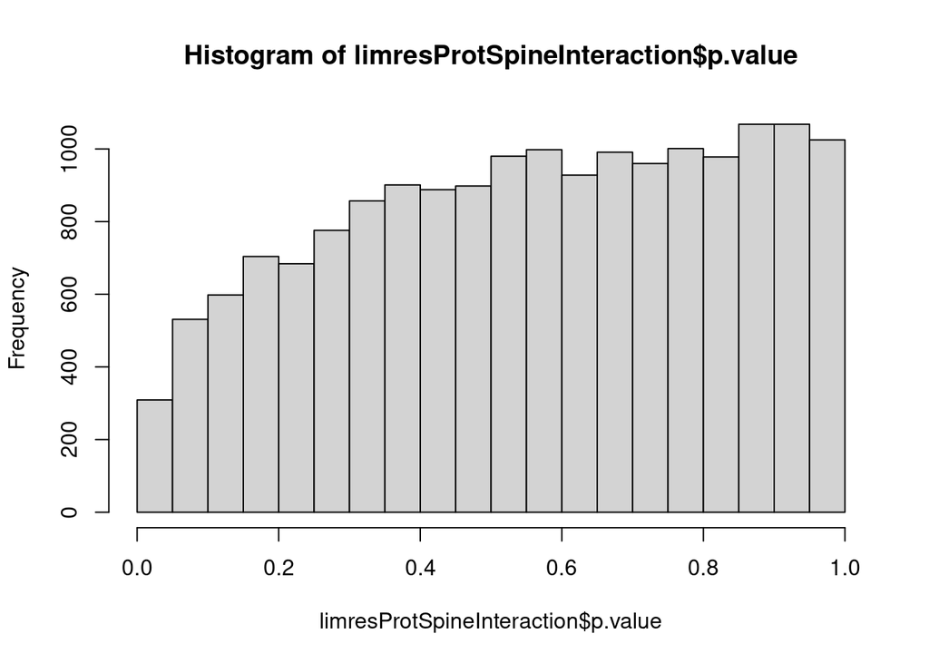

```r
# limma: nothing with FDR < 0.05
modSpineInt=model.matrix(~ as.numeric(pheno$Group=='Sz') + spine.dens[1,] + as.numeric(pheno$Group=='Sz'):spine.dens[1,])
colnames(modSpineInt)[4] = "SzSpine"
limresProtSpineInteraction=fitLimma(protein, modSpineInt , "SzSpine - 0")
hist(limresProtSpineInteraction$p.value)
```

```r
topTable(limresProtSpineInteraction, n=50)
```

```
##                 logFC      AveExpr         t      P.Value adj.P.Val         B
## pO14976     1.0941124 -0.114755389  3.533019 0.0004202093  0.999942 -4.058568
## pQ9C0D0.1  -1.0546524  0.088192966 -3.418221 0.0006425060  0.999942 -4.095722
## pQ9H307.2  -0.9811641 -0.026081526 -3.160182 0.0016004114  0.999942 -4.175194
## RAE2        0.9708722 -0.032783991  3.133518 0.0017524109  0.999942 -4.183047
## pQ9UKM9.2   0.9545776  0.047920470  3.080798 0.0020927219  0.999942 -4.198381
## pQ5T200.4  -0.9244881  0.094905259 -2.989077 0.0028324904  0.999942 -4.224451
## pQ96AG3.1  -0.9133800  0.149839498 -2.943205 0.0032859246  0.999942 -4.237198
## VAMP3.syn  -0.9053292  0.023957278 -2.928646 0.0034424237  0.999942 -4.241177
## pQ15036.2  -0.8944883  0.098190999 -2.890277 0.0038907264  0.999942 -4.251665
## MADD.syn    0.8904018 -0.012444675  2.885051 0.0039539454  0.999942 -4.253026
## pQ96DZ5.2  -0.8854259 -0.012282890 -2.866937 0.0041865147  0.999942 -4.257910
## COMD7      -0.8730765  0.072204941 -2.824640 0.0047795037  0.999942 -4.269220
## SCRB2      -0.8654400  0.171125089 -2.795426 0.0052328866  0.999942 -4.276945
## pO94885    -0.8647682  0.039275895 -2.793936 0.0052569549  0.999942 -4.277335
## ISLR2.syn   0.8663653 -0.064957691  2.793786 0.0052593889  0.999942 -4.277375
## pQ92558.1   0.8531449  0.127026982  2.762163 0.0057926566  0.999942 -4.285569
## pQ4KWH8     0.8485503 -0.049718468  2.735110 0.0062912646  0.999942 -4.292588
## VATG1       0.8457072 -0.179246216  2.733918 0.0063139909  0.999942 -4.292894
## PAHX        0.8444076 -0.004784692  2.725984 0.0064671923  0.999942 -4.294926
## T22D1       0.8413473 -0.077676653  2.723571 0.0065122157  0.999942 -4.295501
## pP17096.4   0.8418152  0.028179269  2.717764 0.0066294440  0.999942 -4.297025
## pO75419    -0.8397514 -0.001372557 -2.711390 0.0067577785  0.999942 -4.298648
## pQ02779.1   0.8308319 -0.073848496  2.679838 0.0074264842  0.999942 -4.306628
## F234A.syn   0.8265970 -0.013310050  2.668053 0.0076911176  0.999942 -4.309585
## MAP6        0.8157696 -0.080131287  2.638128 0.0084008855  0.999942 -4.317027
## pO60641.4   0.8037731  0.118298690  2.606727 0.0092067709  0.999942 -4.324730
## SELK        0.8082541 -0.120628047  2.606189 0.0092238892  0.999942 -4.324896
## pQ9Y2W1.8   0.8063081 -0.088438838  2.603932 0.0092846388  0.999942 -4.325448
## pP07910     0.8057913 -0.054492961  2.601851 0.0093409690  0.999942 -4.325957
## pQ6ZSS7     0.8029955  0.055028321  2.599613 0.0093991691  0.999942 -4.326469
## pO00499.4  -0.8044688 -0.018514173 -2.594255 0.0095491706  0.999942 -4.327809
## CPLX3       0.8004175 -0.153025385  2.585078 0.0098062473  0.999942 -4.330040
## GCST.syn    0.7978263  0.055264168  2.570697 0.0102214980  0.999942 -4.333521
## PMA6F.syn   0.7954905 -0.072271394  2.565111 0.0103869877  0.999942 -4.334867
## JMY.syn     0.7918211 -0.064559340  2.561075 0.0105070104  0.999942 -4.335827
## pQ6XYQ8    -0.7923350  0.029694553 -2.559623 0.0105518813  0.999942 -4.336188
## pQ86XL3.1   0.7922094 -0.006051070  2.551005 0.0108155139  0.999942 -4.338255
## pO14490.10  0.7858610 -0.113513953  2.548626 0.0108863686  0.999942 -4.338793
## pQ05519.9  -0.7847814  0.015493243 -2.537667 0.0112346622  0.999942 -4.341437
## pQ9UQB3.9  -0.7812980 -0.077219595 -2.531113 0.0114435429  0.999942 -4.342971
## PPT1       -0.7844540  0.007163863 -2.531040 0.0114489432  0.999942 -4.343019
## pQ6ZMQ8    -0.7847224  0.063274313 -2.531035 0.0114491039  0.999942 -4.343020
## DHX9.syn    0.7811153 -0.005957565  2.529476 0.0114968849  0.999942 -4.343360
## pQ9BZF1.2   0.7808717 -0.045893405  2.528654 0.0115237442  0.999942 -4.343555
## pQ9H4G0.9   0.7828786 -0.069559209  2.525599 0.0116271587  0.999942 -4.344310
## DC1L2.syn   0.7821523  0.060549549  2.523608 0.0116930180  0.999942 -4.344783
## pP13646.1   0.7829782  0.053487300  2.521861 0.0117510554  0.999942 -4.345196
## pQ9Y2H5    -0.7800237  0.125681663 -2.516316 0.0119369783  0.999942 -4.346508
## CTTB2.syn   0.7762186 -0.087949942  2.509908 0.0121546970  0.999942 -4.348017
## pP60201.4  -0.7753203  0.113416050 -2.502508 0.0124113128  0.999942 -4.349762
```

## causal graph construction

1. Sampling function Returns a list of sampling results

```r
graphSampling <- function(protein, LV, spine, prot.use, pheno = NULL, spinePredict = NULL, n = 20, lambda1 = 0.1) {
    graph_list = list()
    for (i in 1:n) {
        prot.sub = unique(sample(prot.use, replace=T))
        nt.data = cbind(t(protein[prot.sub,]), t(LV), "Spine" = spine)
        if(!is.null(pheno)) {
            nt.data = cbind(nt.data, "Sz" = pheno)
        }
        if (!is.null(spinePredict)) {
            nt.data = cbind(nt.data, t(spinePredict))
        }
        ntres = notearsInterceptMultiLoss(nt.data, lambda1 = lambda1)
        graph = ntres$graph
        graph_list[[i]]=graph
    }
    graph_list
}
```

2. graph construction function Input graph list

```r
graphConstruction <- function (graph_list, name, thres = 0.2, n = 20, n_cutoff = 10) {
    l = length(name)
    newgraph = matrix(data=c(0.0), nrow = l, ncol = l)
    rownames(newgraph) = name
    colnames(newgraph) = rownames(newgraph)

    for (i in 1:l) {
        for (j in 1:l) {
            cnt = 0;
            sum = 0.0;
            row_name=name[i]
            col_name=name[j]
            for (k in 1:n) {
                namek = rownames(graph_list[[k]])
                if (row_name %in% namek & col_name %in% namek) {
                    if(abs(graph_list[[k]][row_name, col_name]) >= thres) {
                        cnt = cnt+1;
                        sum = sum + graph_list[[k]][row_name, col_name]
                    }
                }
            }
            if (cnt >= n_cutoff) {
                newgraph[i,j] = 1.0*sum/cnt
            }
        }
    }
    newgraph
}
```

3. Feature selection Focal variable: Diagnosis Nodes

```r
prot.use = toLabel
lv.use = colnames(res$Z)[which(colSums(res$Z[prot.use,])>0)]
```

Sample defalut n=20

```r
SampleDx_Predict = graphSampling(protein = protein, LV = tscale(res$B[lv.use,]), spine = spine.dens[7,], prot.use = prot.use,
                                 pheno = pheno$Group=="Sz", spinePredict = spinePredict)
```

```
## The losses are
```

```
## losses
##       l2 logistic
##       31        1
```

```
## The losses are
```

```
## losses
##       l2 logistic
##       27        1
```

```
## The losses are
```

```
## losses
##       l2 logistic
##       28        1
```

```
## The losses are
```

```
## losses
##       l2 logistic
##       31        1
```

```
## The losses are
```

```
## losses
##       l2 logistic
##       28        1
```

```
## The losses are
```

```
## losses
##       l2 logistic
##       31        1
```

```
## The losses are
```

```
## losses
##       l2 logistic
##       25        1
```

```
## The losses are
```

```
## losses
##       l2 logistic
##       29        1
```

```
## The losses are
```

```
## losses
##       l2 logistic
##       29        1
```

```
## The losses are
```

```
## losses
##       l2 logistic
##       27        1
```

```
## The losses are
```

```
## losses
##       l2 logistic
##       30        1
```

```
## The losses are
```

```
## losses
##       l2 logistic
##       28        1
```

```
## The losses are
```

```
## losses
##       l2 logistic
##       29        1
```

```
## The losses are
```

```
## losses
##       l2 logistic
##       29        1
```

```
## The losses are
```

```
## losses
##       l2 logistic
##       29        1
```

```
## The losses are
```

```
## losses
##       l2 logistic
##       31        1
```

```
## The losses are
```

```
## losses
##       l2 logistic
##       29        1
```

```
## The losses are
```

```
## losses
##       l2 logistic
##       28        1
```

```
## The losses are
```

```
## losses
##       l2 logistic
##       28        1
```

```
## The losses are
```

```
## losses
##       l2 logistic
##       32        1
```

```r
SampleDx_NoSz_Predict = graphSampling(protein = protein, LV = tscale(res$B[lv.use,]), spine = spine.dens[7,], prot.use = prot.use,
                                      spinePredict = spinePredict)
```

```
## The losses are
```

```
## losses
## l2
## 28
```

```
## The losses are
```

```
## losses
## l2
## 29
```

```
## The losses are
```

```
## losses
## l2
## 29
```

```
## The losses are
```

```
## losses
## l2
## 31
```

```
## The losses are
```

```
## losses
## l2
## 27
```

```
## The losses are
```

```
## losses
## l2
## 26
```

```
## The losses are
```

```
## losses
## l2
## 29
```

```
## The losses are
```

```
## losses
## l2
## 28
```

```
## The losses are
```

```
## losses
## l2
## 26
```

```
## The losses are
```

```
## losses
## l2
## 30
```

```
## The losses are
```

```
## losses
## l2
## 27
```

```
## The losses are
```

```
## losses
## l2
## 29
```

```
## The losses are
```

```
## losses
## l2
## 29
```

```
## The losses are
```

```
## losses
## l2
## 27
```

```
## The losses are
```

```
## losses
## l2
## 31
```

```
## The losses are
```

```
## losses
## l2
## 27
```

```
## The losses are
```

```
## losses
## l2
## 29
```

```
## The losses are
```

```
## losses
## l2
## 30
```

```
## The losses are
```

```
## losses
## l2
## 31
```

```
## The losses are
```

```
## losses
## l2
## 24
```

```r
SampleDx = graphSampling(protein = protein, LV = tscale(res$B[lv.use,]), spine = spine.dens[7,], prot.use = prot.use,
                         pheno = pheno$Group=="Sz")
```

```
## The losses are
```

```
## losses
##       l2 logistic
##       26        1
```

```
## The losses are
```

```
## losses
##       l2 logistic
##       26        1
```

```
## The losses are
```

```
## losses
##       l2 logistic
##       27        1
```

```
## The losses are
```

```
## losses
##       l2 logistic
##       23        1
```

```
## The losses are
```

```
## losses
##       l2 logistic
##       24        1
```

```
## The losses are
```

```
## losses
##       l2 logistic
##       26        1
```

```
## The losses are
```

```
## losses
##       l2 logistic
##       26        1
```

```
## The losses are
```

```
## losses
##       l2 logistic
##       26        1
```

```
## The losses are
```

```
## losses
##       l2 logistic
##       23        1
```

```
## The losses are
```

```
## losses
##       l2 logistic
##       27        1
```

```
## The losses are
```

```
## losses
##       l2 logistic
##       23        1
```

```
## The losses are
```

```
## losses
##       l2 logistic
##       23        1
```

```
## The losses are
```

```
## losses
##       l2 logistic
##       28        1
```

```
## The losses are
```

```
## losses
##       l2 logistic
##       26        1
```

```
## The losses are
```

```
## losses
##       l2 logistic
##       29        1
```

```
## The losses are
```

```
## losses
##       l2 logistic
##       27        1
```

```
## The losses are
```

```
## losses
##       l2 logistic
##       23        1
```

```
## The losses are
```

```
## losses
##       l2 logistic
##       25        1
```

```
## The losses are
```

```
## losses
##       l2 logistic
##       23        1
```

```
## The losses are
```

```
## losses
##       l2 logistic
##       26        1
```

```r
SampleDx_NoSz = graphSampling(protein = protein, LV = tscale(res$B[lv.use,]), spine = spine.dens[7,], prot.use = prot.use)
```

```
## The losses are
```

```
## losses
## l2
## 25
```

```
## The losses are
```

```
## losses
## l2
## 26
```

```
## The losses are
```

```
## losses
## l2
## 25
```

```
## The losses are
```

```
## losses
## l2
## 25
```

```
## The losses are
```

```
## losses
## l2
## 23
```

```
## The losses are
```

```
## losses
## l2
## 27
```

```
## The losses are
```

```
## losses
## l2
## 23
```

```
## The losses are
```

```
## losses
## l2
## 27
```

```
## The losses are
```

```
## losses
## l2
## 23
```

```
## The losses are
```

```
## losses
## l2
## 27
```

```
## The losses are
```

```
## losses
## l2
## 23
```

```
## The losses are
```

```
## losses
## l2
## 23
```

```
## The losses are
```

```
## losses
## l2
## 25
```

```
## The losses are
```

```
## losses
## l2
## 24
```

```
## The losses are
```

```
## losses
## l2
## 27
```

```
## The losses are
```

```
## losses
## l2
## 25
```

```
## The losses are
```

```
## losses
## l2
## 23
```

```
## The losses are
```

```
## losses
## l2
## 27
```

```
## The losses are
```

```
## losses
## l2
## 22
```

```
## The losses are
```

```
## losses
## l2
## 28
```

look at top 20/30/50 edge cutoff

```r
for (i in 1:20) {
    sorted = sort(abs(SampleDx_NoSz[[i]]), T)
    print(c(sorted[21], sorted[31], sorted[51]))
}
```

```
## [1] 0.3145063 0.2374462 0.1091373
## [1] 0.3224702 0.2145844 0.1313183
## [1] 0.2522897 0.2115767 0.1281187
## [1] 0.2978440 0.2131686 0.1193367
## [1] 0.3054149 0.1865630 0.1091186
## [1] 0.3221980 0.2355893 0.1423221
## [1] 0.2449642 0.1825680 0.1007088
## [1] 0.3067167 0.2248912 0.1318031
## [1] 0.3072119 0.2143961 0.1103152
## [1] 0.3142800 0.2533247 0.1303097
## [1] 0.28576764 0.21263789 0.09768005
## [1] 0.26441946 0.20096617 0.09956378
## [1] 0.3344758 0.2286269 0.1042173
## [1] 0.36818898 0.18746656 0.07673189
## [1] 0.3077850 0.2394423 0.1377836
## [1] 0.36080696 0.21880214 0.09615073
## [1] 0.2628850 0.1831733 0.1003428
## [1] 0.3118974 0.2178377 0.1297581
## [1] 0.28604943 0.16659888 0.08263283
## [1] 0.3465076 0.2230958 0.1348303
```

Construct new graph with default threshold=0.2

```r
name = c(prot.use, lv.use, "Spine", "Sz", rownames(spinePredict))
GraphDx_Predict = graphConstruction(graph_list = SampleDx_Predict, name = name)

name = c(prot.use, lv.use, "Spine", rownames(spinePredict))
GraphDx_NoSz_Predict = graphConstruction(graph_list = SampleDx_NoSz_Predict, name = name)

name = c(prot.use, lv.use, "Spine", "Sz")
GraphDx = graphConstruction(graph_list = SampleDx, name = name)

name = c(prot.use, lv.use, "Spine")
GraphDx_NoSz = graphConstruction(graph_list = SampleDx_NoSz, name = name)
```

Visualize

```r
# graph varType
SYN=length(grep(".syn", prot.use))
Phos=length(grep("p", prot.use))
HOM=length(prot.use)-SYN-Phos
Prot = c(rep("Phos", Phos), rep("Hom", HOM), rep("Syn", SYN))
lenLV = rep("LV",length(lv.use))
```

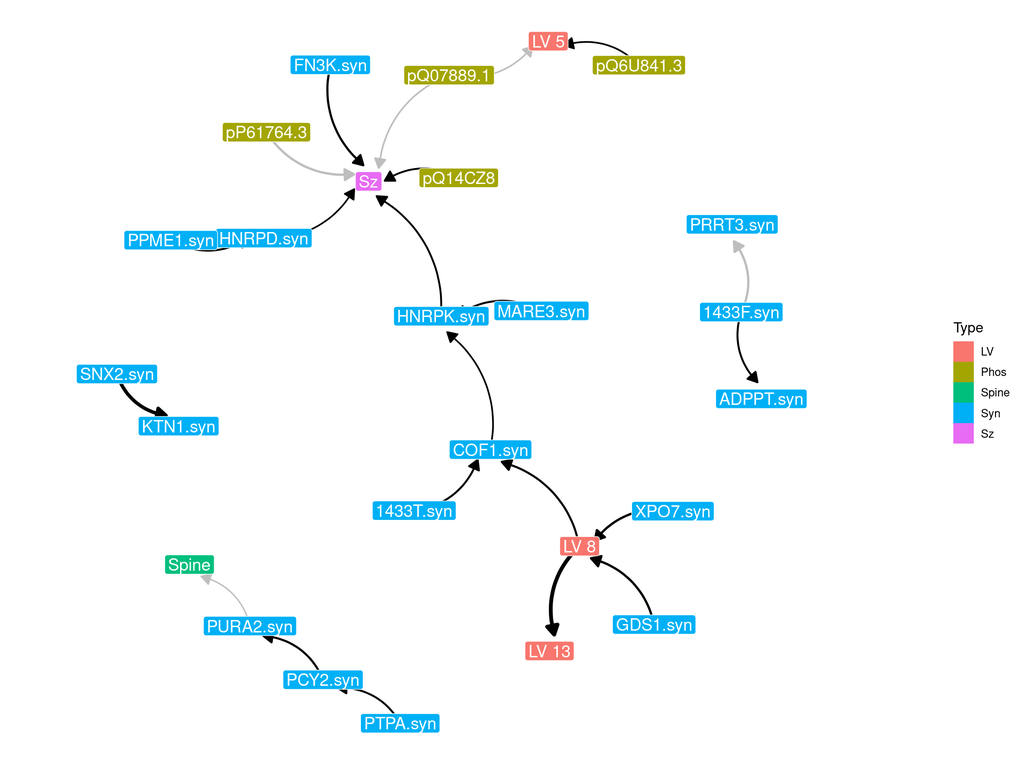

```r
gvarType = c(Prot, lenLV, "Spine", "Sz", "PredictSpine")
network_visualize(GraphDx_Predict, gvarType)
```

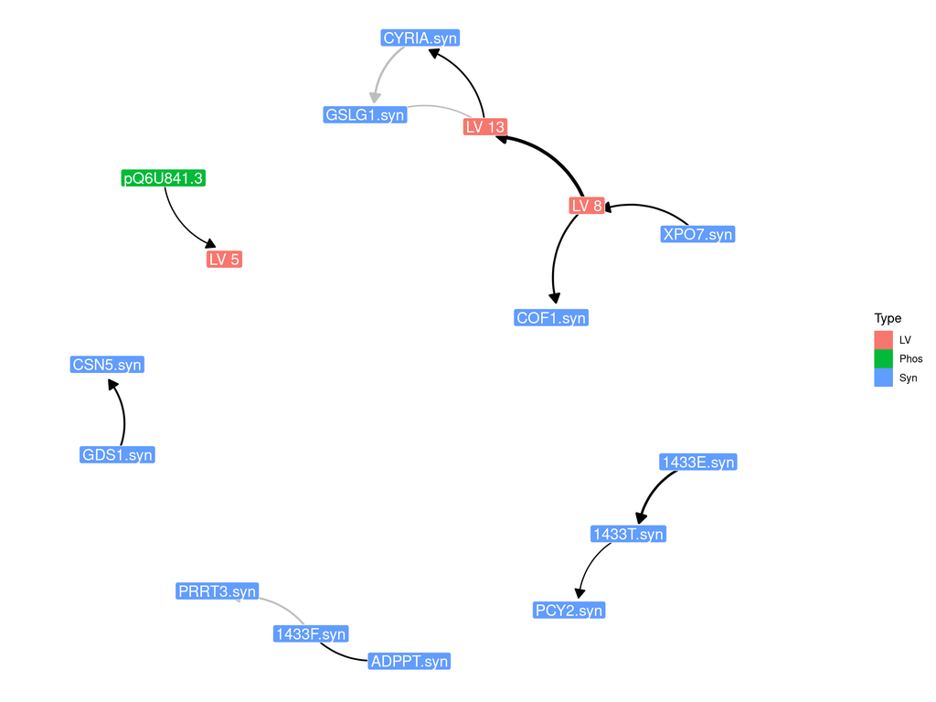

```r
gvarType = c(Prot, lenLV, "Spine", "PredictSpine")
network_visualize(GraphDx_NoSz_Predict, gvarType)
```

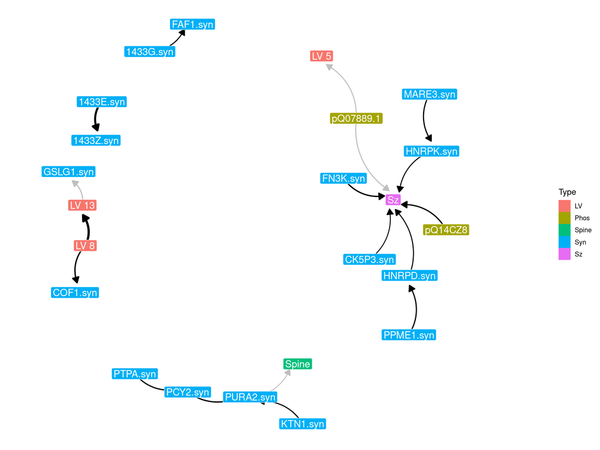

```r
gvarType = c(Prot, lenLV, "Spine", "Sz")
network_visualize(GraphDx, gvarType)
```

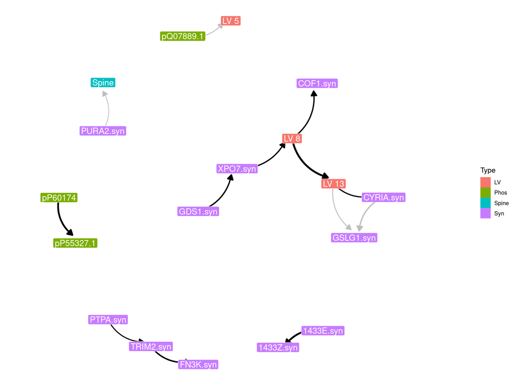

```r
gvarType = c(Prot, lenLV, "Spine")
network_visualize(GraphDx_NoSz, gvarType)
```

```r
gvarType = c("Sz",
             rep("Spine_Sz", 11), rep("Spine_Ctrl", 20),
             rep("LV",length(lv.use)), "Spine")
```

4. Feature selection Focal variable: Average spine density S Nodes

```r
prot.use = toLabel.Spine
lv.use = colnames(res$Z)[which(colSums(res$Z[prot.use,])>0)]
```

Sample defalut n=20

```r
SampleSpine_Predict = graphSampling(protein = protein, LV = tscale(res$B[lv.use,]), spine = spine.dens[7,], prot.use = prot.use,
                                 pheno = pheno$Group=="Sz", spinePredict = spinePredict)
```

```
## The losses are
```

```
## losses
##       l2 logistic
##       28        1
```

```
## The losses are
```

```
## losses
##       l2 logistic
##       28        1
```

```
## The losses are
```

```
## losses
##       l2 logistic
##       28        1
```

```
## The losses are
```

```
## losses
##       l2 logistic
##       27        1
```

```
## The losses are
```

```
## losses
##       l2 logistic
##       28        1
```

```
## The losses are
```

```
## losses
##       l2 logistic
##       27        1
```

```
## The losses are
```

```
## losses
##       l2 logistic
##       29        1
```

```
## The losses are
```

```
## losses
##       l2 logistic
##       25        1
```

```
## The losses are
```

```
## losses
##       l2 logistic
##       30        1
```

```
## The losses are
```

```
## losses
##       l2 logistic
##       29        1
```

```
## The losses are
```

```
## losses
##       l2 logistic
##       27        1
```

```
## The losses are
```

```
## losses
##       l2 logistic
##       29        1
```

```
## The losses are
```

```
## losses
##       l2 logistic
##       29        1
```

```
## The losses are
```

```
## losses
##       l2 logistic
##       28        1
```

```
## The losses are
```

```
## losses
##       l2 logistic
##       28        1
```

```
## The losses are
```

```
## losses
##       l2 logistic
##       27        1
```

```
## The losses are
```

```
## losses
##       l2 logistic
##       29        1
```

```
## The losses are
```

```
## losses
##       l2 logistic
##       26        1
```

```
## The losses are
```

```
## losses
##       l2 logistic
##       27        1
```

```
## The losses are
```

```
## losses
##       l2 logistic
##       26        1
```

```r
SampleSpine_NoSz_Predict = graphSampling(protein = protein, LV = tscale(res$B[lv.use,]), spine = spine.dens[7,], prot.use = prot.use,
                                      spinePredict = spinePredict)
```

```
## The losses are
```

```
## losses
## l2
## 27
```

```
## The losses are
```

```
## losses
## l2
## 28
```

```
## The losses are
```

```
## losses
## l2
## 30
```

```
## The losses are
```

```
## losses
## l2
## 25
```

```
## The losses are
```

```
## losses
## l2
## 29
```

```
## The losses are
```

```
## losses
## l2
## 28
```

```
## The losses are
```

```
## losses
## l2
## 30
```

```
## The losses are
```

```
## losses
## l2
## 25
```

```
## The losses are
```

```
## losses
## l2
## 28
```

```
## The losses are
```

```
## losses
## l2
## 28
```

```
## The losses are
```

```
## losses
## l2
## 26
```

```
## The losses are
```

```
## losses
## l2
## 29
```

```
## The losses are
```

```
## losses
## l2
## 27
```

```
## The losses are
```

```
## losses
## l2
## 29
```

```
## The losses are
```

```
## losses
## l2
## 27
```

```
## The losses are
```

```
## losses
## l2
## 28
```

```
## The losses are
```

```
## losses
## l2
## 30
```

```
## The losses are
```

```
## losses
## l2
## 27
```

```
## The losses are
```

```
## losses
## l2
## 28
```

```
## The losses are
```

```
## losses
## l2
## 30
```

```r
SampleSpine = graphSampling(protein = protein, LV = tscale(res$B[lv.use,]), spine = spine.dens[7,], prot.use = prot.use,
                         pheno = pheno$Group=="Sz")
```

```
## The losses are
```

```
## losses
##       l2 logistic
##       23        1
```

```
## The losses are
```

```
## losses
##       l2 logistic
##       27        1
```

```
## The losses are
```

```
## losses
##       l2 logistic
##       26        1
```

```
## The losses are
```

```
## losses
##       l2 logistic
##       24        1
```

```
## The losses are
```

```
## losses
##       l2 logistic
##       26        1
```

```
## The losses are
```

```
## losses
##       l2 logistic
##       24        1
```

```
## The losses are
```

```
## losses
##       l2 logistic
##       25        1
```

```
## The losses are
```

```
## losses
##       l2 logistic
##       25        1
```

```
## The losses are
```

```
## losses
##       l2 logistic
##       27        1
```

```
## The losses are
```

```
## losses
##       l2 logistic
##       23        1
```

```
## The losses are
```

```
## losses
##       l2 logistic
##       24        1
```

```
## The losses are
```

```
## losses
##       l2 logistic
##       26        1
```

```
## The losses are
```

```
## losses
##       l2 logistic
##       26        1
```

```
## The losses are
```

```
## losses
##       l2 logistic
##       23        1
```

```
## The losses are
```

```
## losses
##       l2 logistic
##       24        1
```

```
## The losses are
```

```
## losses
##       l2 logistic
##       24        1
```

```
## The losses are
```

```
## losses
##       l2 logistic
##       25        1
```

```
## The losses are
```

```
## losses
##       l2 logistic
##       27        1
```

```
## The losses are
```

```
## losses
##       l2 logistic
##       25        1
```

```
## The losses are
```

```
## losses
##       l2 logistic
##       22        1
```

```r
SampleSpine_NoSz = graphSampling(protein = protein, LV = tscale(res$B[lv.use,]), spine = spine.dens[7,], prot.use = prot.use)
```

```
## The losses are
```

```
## losses
## l2
## 24
```

```
## The losses are
```

```
## losses
## l2
## 24
```

```
## The losses are
```

```
## losses
## l2
## 23
```

```
## The losses are
```

```
## losses
## l2
## 26
```

```
## The losses are
```

```
## losses
## l2
## 25
```

```
## The losses are
```

```
## losses
## l2
## 27
```

```
## The losses are
```

```
## losses
## l2
## 23
```

```
## The losses are
```

```
## losses
## l2
## 23
```

```
## The losses are
```

```
## losses
## l2
## 24
```

```
## The losses are
```

```
## losses
## l2
## 27
```

```
## The losses are
```

```
## losses
## l2
## 22
```

```
## The losses are
```

```
## losses
## l2
## 23
```

```
## The losses are
```

```
## losses
## l2
## 25
```

```
## The losses are
```

```
## losses
## l2
## 23
```

```
## The losses are
```

```
## losses
## l2
## 25
```

```
## The losses are
```

```
## losses
## l2
## 25
```

```
## The losses are
```

```
## losses
## l2
## 24
```

```
## The losses are
```

```
## losses
## l2
## 25
```

```
## The losses are
```

```
## losses
## l2
## 23
```

```
## The losses are
```

```
## losses
## l2
## 23
```

look at top 20/30/50 edge cutoff

```r
for (i in 1:20) {
    sorted = sort(abs(SampleSpine_NoSz[[i]]), T)
    print(c(sorted[21], sorted[31], sorted[51]))
}
```

```
## [1] 0.2370961 0.1897996 0.1068307
## [1] 0.2949242 0.1903562 0.1023797
## [1] 0.2436426 0.1890484 0.1052172
## [1] 0.2252138 0.1870481 0.1214016
## [1] 0.2471812 0.1804856 0.1118313
## [1] 0.2776952 0.2085288 0.1265295
## [1] 0.2576596 0.1785483 0.1003897
## [1] 0.26876554 0.18867708 0.08963834
## [1] 0.2656992 0.1969065 0.1017344
## [1] 0.2793434 0.2238078 0.1248678
## [1] 0.23221211 0.16399123 0.08931094
## [1] 0.28153042 0.18236407 0.09256763
## [1] 0.2526117 0.1769733 0.1156945
## [1] 0.2660032 0.2012032 0.1088177
## [1] 0.2462921 0.1875402 0.1236729
## [1] 0.2613810 0.2015451 0.1170398
## [1] 0.2655338 0.1921101 0.1015091
## [1] 0.2501857 0.1785280 0.1229440
## [1] 0.25778072 0.20020182 0.09119487
## [1] 0.27512929 0.18302381 0.09464652
```

Construct new graph with default threshold=0.2

```r
name = c(prot.use, lv.use, "Spine", "Sz", rownames(spinePredict))
GraphSpine_Predict = graphConstruction(graph_list = SampleSpine_Predict, name = name)

name = c(prot.use, lv.use, "Spine", rownames(spinePredict))
GraphSpine_NoSz_Predict = graphConstruction(graph_list = SampleSpine_NoSz_Predict, name = name)

name = c(prot.use, lv.use, "Spine", "Sz")
GraphSpine = graphConstruction(graph_list = SampleSpine, name = name)

name = c(prot.use, lv.use, "Spine")
GraphSpine_NoSz = graphConstruction(graph_list = SampleSpine_NoSz, name = name)
```

Visualize

```r
# graph varType
SYN=length(grep(".syn", prot.use))
Phos=length(grep("p", prot.use))
HOM=length(prot.use)-SYN-Phos
Prot = c(rep("Phos", Phos), rep("Hom", HOM), rep("Syn", SYN))
lenLV = rep("LV",length(lv.use))
```

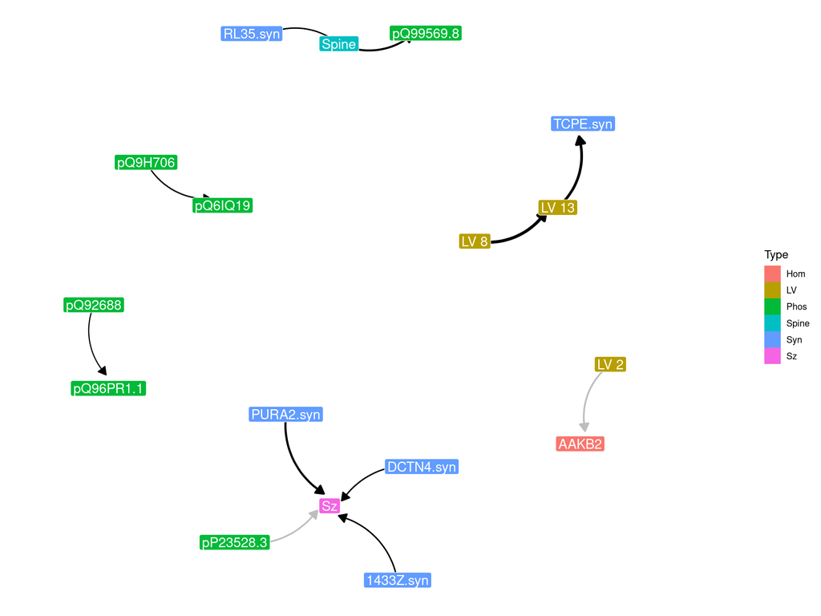

```r
gvarType = c(Prot, lenLV, "Spine", "Sz", "PredictSpine")
network_visualize(GraphSpine_Predict, gvarType)
```

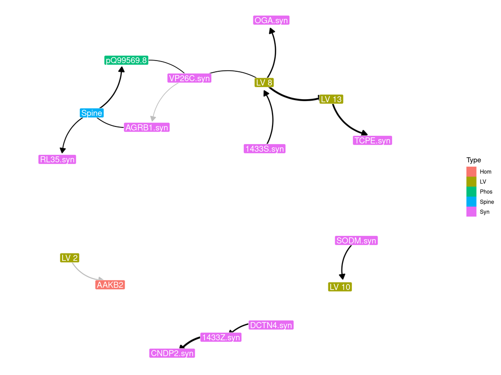

```r
gvarType = c(Prot, lenLV, "Spine", "PredictSpine")
network_visualize(GraphSpine_NoSz_Predict, gvarType)
```

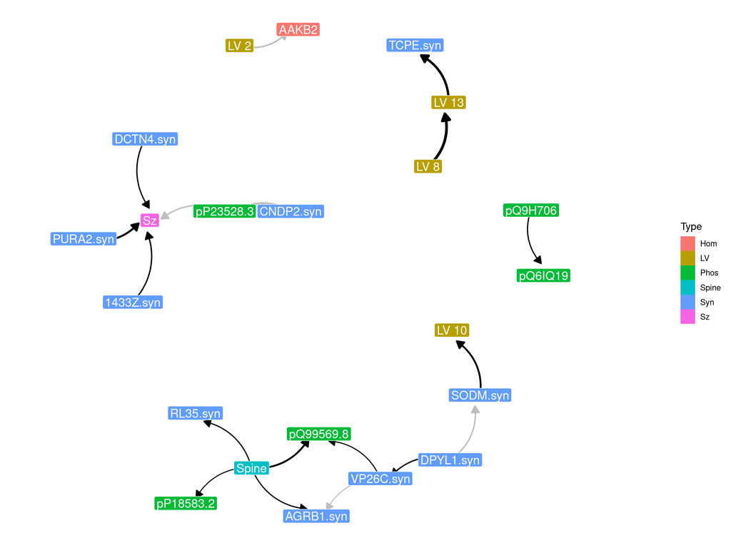

```r
gvarType = c(Prot, lenLV, "Spine", "Sz")
network_visualize(GraphSpine, gvarType)
```

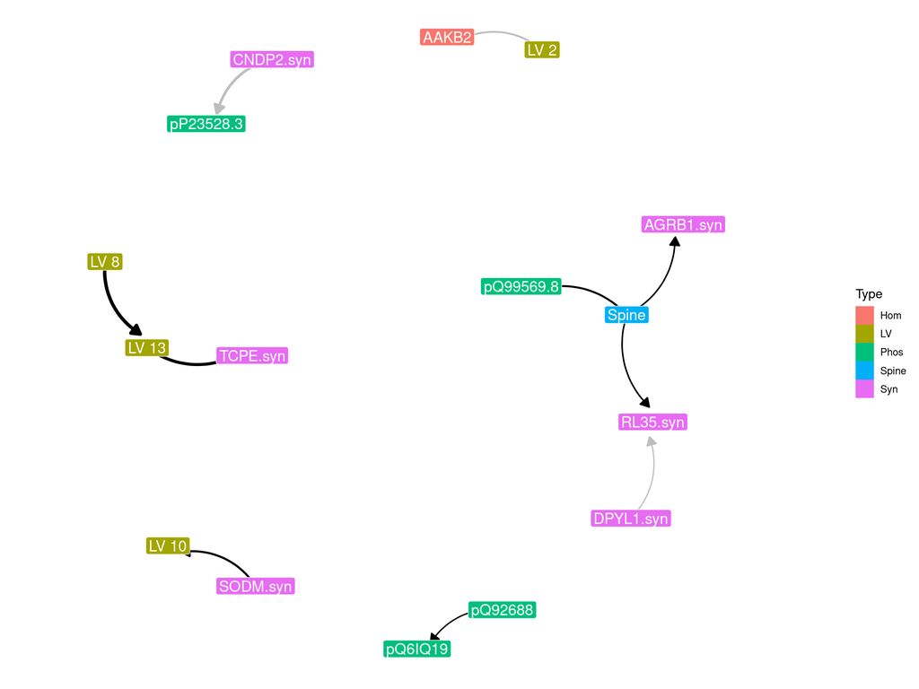

```r
gvarType = c(Prot, lenLV, "Spine")
network_visualize(GraphSpine_NoSz, gvarType)
```

## relationship between LV and pH

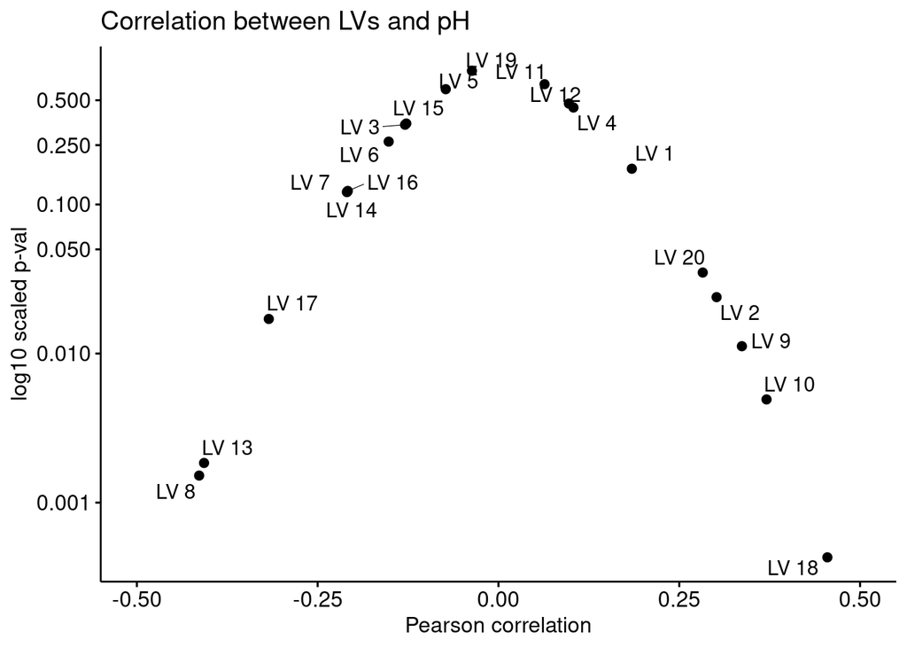

```r
t_res=tscale(res$B)
LV_pH = data.frame()
for (i in 1:nrow(t_res)) {
    cor=cor.test(t_res[i,], pheno$pH)
    a=t(melt(unlist(cor)))
    LV_pH = rbind(LV_pH, a)
}
rownames(LV_pH)=rownames(t_res)
LV_pH=as.data.frame(LV_pH)
LV_pH$p.value=as.numeric(LV_pH$p.value)
LV_pH$estimate.cor=as.numeric(LV_pH$estimate.cor)
ggscatter(LV_pH, "estimate.cor", "p.value", label = rownames(LV_pH), repel = T,
          xlim = c(-0.5, 0.5),
          ylab = "log10 scaled p-val",
          xlab = "Pearson correlation") +
    scale_y_log10(breaks = c(1e-4, 1e-3, 1e-2, 0.05, 0.1, 0.25, 0.5)) +
    labs(title = "Correlation between LVs and pH")
```